# Apply bayesian Graphical Models to multi-omics data

Johann Hawe

```r
#if(params$SNP=="") stop("No sentinel provided!")
#sentinel <- params$SNP
sentinel <- "rs9859077"
```

In this script we load KORA and LOLIPOP data for the sentinel and apply the bayesian GGM algorithm implemented in the BDgraph package to them, using priors for the individual links possible in the underlying graph structure. Priors have to be created beforehand and provided as RData files on the results folder.

## Prior calculation

Now we get the priors for all possible links within the data matrix. The priors need to have been created beforehand and are simply loaded in the called function.

[output not shown]

```
Loading string db
Done.
Prior min-value:  1e-07
Loading string db
Done.
Prior min-value:  1e-07
```

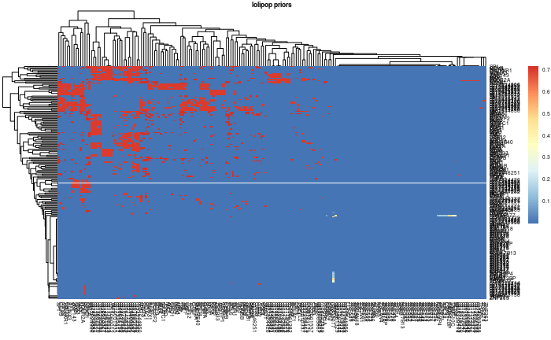

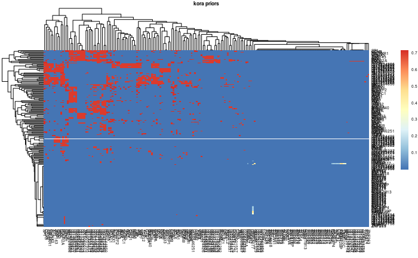

```r
priors <- lapply(cohorts, function(c){
  cohort <- data[[c]]

  # get the prior definitions and plot the prior heatmap
  priors <- get.link.priors(cohort$ranges, cohort$nodes)
  cat("Prior min-value: ", min(priors), "\n")

  pheatmap(priors, cex=0.7, main=paste0(c, " priors"))
  return(priors)
})
```

```r
names(priors) <- cohorts
```

## GGM fit

In the next step we finally fit the GGM to our data, using the priors during the process. First a ‘start-graph’ is created, which serves as the entry point in the calculations for the algorithms. Afterwards we can start running the bdgraph algorithm in order to get our partial correlations based on data and prior knowledge.

[figure not shown]

[figure not shown]

```r
iter=100000
burnin=50000
cores=10
```

```r
fits <- lapply(cohorts, function(c){
  gdata <- data[[c]]$data
  id <- data[[c]]$id
  ranges <- data[[c]]$ranges
  gstart <- gstarts[[c]]
  gpriors <- priors[[c]]
  ggm.fit <- bdgraph(gdata,
          method="gcgm",
          iter=iter,
          burnin=burnin,
          save.all=T, g.start = gstart,
          g.prior = gpriors, cores=cores)

  graph <- graph.from.fit(ggm.fit, ranges)
  if(length(nodes(graph))<1){
    warning("Resulting graph has no nodes.")
  } else {

    plot.data <- plot.ggm(g=graph, id=id, dot.out = paste0("results/", sentinel, ".", c, ".fit.dot"))
    save(file=paste0("results/", sentinel, ".", c, ".fit.RData"),
         ggm.fit, ranges, gdata, gstart, gpriors, graph, plot.data)
  }
  # check some plots
  ggm.summary <- summary(ggm.fit)
  traceplot(ggm.fit)
  plotcoda(ggm.fit)
  return(list(ggm.fit = ggm.fit, graph=graph, ranges=ranges, summary = ggm.summary))
})
```

[output not shown]